# Mistrzostwa Świata/Igrzyska Olimpijskie w Judo 2000–2019

TP

2/12/2019

## Dane

Ze strony https://judobase.ijf.org/ pobrano dane dotyczące turniejów o Mistrzostwo Świata w judo oraz turnieju judo na Igrzyskach Olimpijskich w latach 2000–2019. Dało się je zwględnie sprawnie zamienić na plik csv:

```r
d <- read.csv("jbase_2000_2019.csv", sep = ';', dec = ",",  header=T, na.string="NA");

names(d)
```

```
##  [1] "event"  "year"   "cat"    "sex"    "fid"    "cntry1" "name1"  "winner"
##  [9] "name2"  "cntry2" "score1" "score2" "time"   "round"  "idr"    "ippon"
## [17] "stime"  "in."    "wn"     "yn"
```

```r
fN <- nrow(d)
fNvalid <- nrow(na.omit(d))
```

plik zawiera 7002 walk. Poszczególne kolumny zawierają: event – symbol trumieju (oo albo wc); year – rok; cat – kategoria wagowa (178/200 to umowny zapisa dla kategorii +78 oraz +100); sex – płeć; fid – id walki (nieużywane); cntry1 – kraj zawodnika z kolumny następnej; name1 – imię nazwisko; winner – zwycięzca (L/R jeżeli L to pierwszy zawodnik w wierszy/R drugi); name2 – imię nazwisko; cntry2 – kraj zawodnika z poprzedniej kolumny –; score1 – wynik zawodnika 1 (zapis i w y = ostrzeżenia; iwy są opcjonalne, jeżeli ich nie było, tj może być zapis 1 (równoważny 0 0 1) lub 1 1 (równoważny 0 1 1)); score2 – wynik zawodnika 2 (zapis i w y = ostrzeżenia); time – czas walki (mm:ss); round – runda turnieju; idr – id rundy turnieju; ippon – czy koniec przez ippon (1/tak, 0/nie); stime – czas walki w sekundach; in – liczba ippon (1 lub zero/kopia zmiennej ippon) ; wn – liczba wazari ; yn – liczba yuka.

Uwaga: ja ani nie jestem judoką ani kibicem judo. Powyższe ustaliłem `na szybko’, więc może coś pomyliłem (zwłaszcza dotyczy to punktacji).

Uwaga2: czas walki czasamy jest absurdalnie długi albo podjerzanie krótki. Arbitralnie podjąłem decyzję że walki dłuże niż 480 s (8 minut) albo krótsze niż 2 s mają błędny czas i oznaczam wartość jako NA (zmienna stime). Jeżeli powyższa arbitralna decyzja jest zła to każdy może sobie obliczyć czas samodzielnie (na podstawie zmiennej time). Walk oznaczonych jak NA jest 329 (czyli 4.70%)

## Długość walki

Do porówania długość walki w poszczególnych latach (odzielnie kobiety `df` i mężczyźni `dm`) wykorzystano wykres pudełkowy. Ponieważ zmienna `year` jest liczbą, zamieniamy ją wcześniej na czynnik:

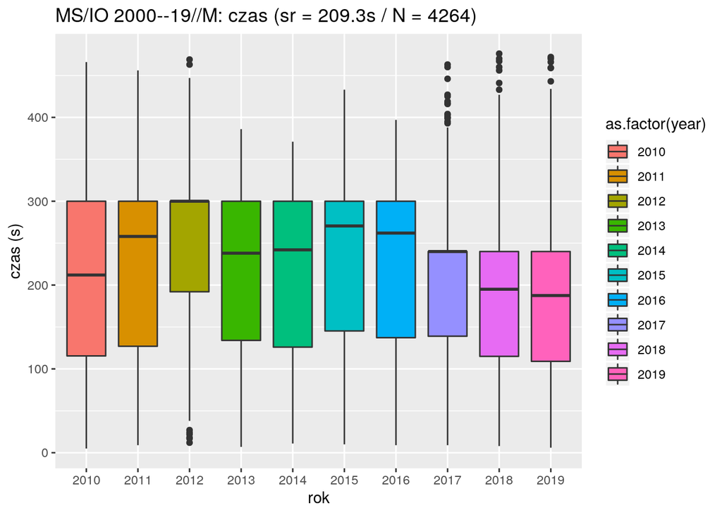

```r
require(ggplot2)
require(dplyr)

dm <- d %>% filter(sex=="M") %>% as.data.frame
df <- d %>% filter(sex=="F") %>% as.data.frame

nm <- nrow(dm)
nf <- nrow(df)

tit.m <-  sprintf("MS/IO 2000--19//M: czas (sr = %.1fs / N = %i)",
                  mean(dm$stime, na.rm=T), nm)
tit.f <-  sprintf("MS/IO 2000--19//K: czas (sr = %.1fs / N = %i)",
                  mean(df$stime, na.rm=T), nf)

ggplot(dm, aes(x=as.factor(year), y=stime, fill=as.factor(year))) + geom_boxplot() + ylab("czas (s)") + ggtitle(tit.m) +
  xlab("rok");
```

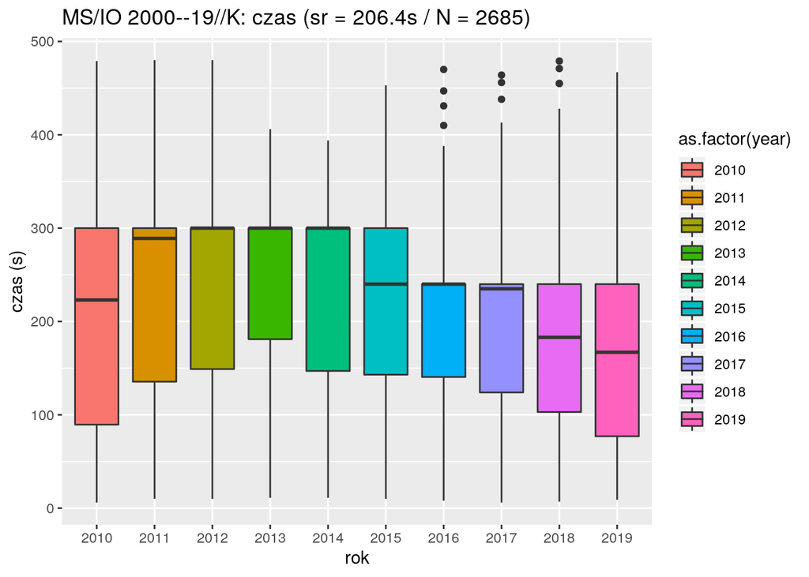

```r
ggplot(df, aes(x=as.factor(year), y=stime, fill=as.factor(year))) +
  geom_boxplot() + ylab("czas (s)") +
  ggtitle(tit.f) +
  xlab("rok");
```

```r
ddm <- dm %>%
  mutate(cat = factor(year)) %>%
  group_by (cat) %>%
  summarise(
    pmean = mean(stime, na.rm=TRUE),
    pmedian = median(stime, na.rm=TRUE)
  ) %>%
  as.data.frame
ddf <- df %>%
  mutate(cat = factor(year)) %>%
  group_by (cat) %>%
  summarise(
    pmean = mean(stime, na.rm=TRUE),
    pmedian = median(stime, na.rm=TRUE)
  ) %>%
  as.data.frame
```

Wartości średnie czasu walki w poszczególnych latach:

```r
ddm
```

```
##     cat    pmean pmedian
## 1  2010 206.9021   212.0
## 2  2011 216.5029   258.0
## 3  2012 253.0205   300.0
## 4  2013 212.7605   238.0
## 5  2014 213.0305   242.0
## 6  2015 223.8502   270.5
## 7  2016 221.0709   262.0
## 8  2017 207.5840   240.0
## 9  2018 189.2293   195.0
## 10 2019 184.1531   187.5
```

```r
ddf
```

```
##     cat    pmean pmedian
## 1  2010 202.6290     223
## 2  2011 224.7738     289
## 3  2012 243.4444     300
## 4  2013 238.7946     300
## 5  2014 229.6867     300
## 6  2015 216.4433     240
## 7  2016 199.3509     240
## 8  2017 198.7509     235
## 9  2018 181.0450     183
## 10 2019 166.4657     167
```

## Odsetek walk zakończonych przez ippon

Dane są agregowane dla poszczególnych lat (liczba walk zakończonych ippon/łączna liczba walki) a następnie prezentowane za pomocą wykresu słupkowego (oddzielnie dla kobiet i mężczyzn):

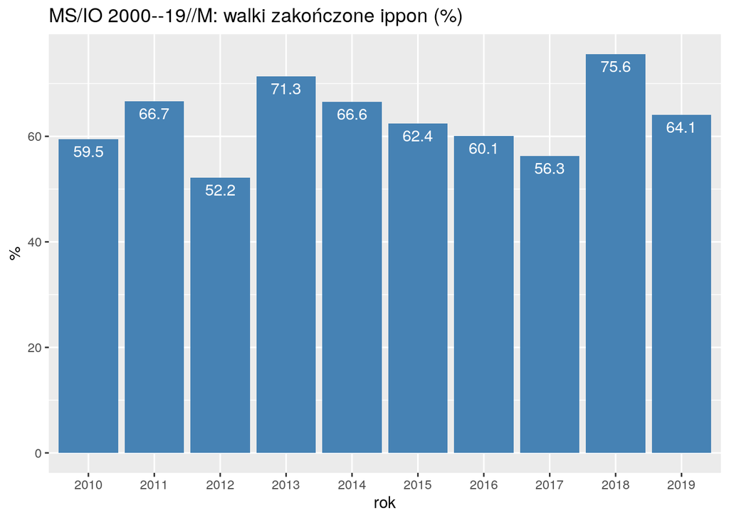

```r
tit.m <-  sprintf("MS/IO 2000--19//M: walki zakończone ippon (%%)")
tit.f <-  sprintf("MS/OI 2000--19//K: walki zakończone ippon (%%)")

dm <- d %>% filter(sex=="M")  %>%
  mutate(yr = factor(year)) %>%
  group_by (yr) %>%
  summarise( pmean = mean(ippon, na.rm=TRUE) * 100,) %>%
  as.data.frame

## ##
df <- d %>% filter(sex=="F") %>%
  mutate(yr = factor(year)) %>%
  group_by (yr) %>%
  summarise( pmean = mean(ippon, na.rm=TRUE) *100,) %>%
  as.data.frame

p.m <- ggplot(dm, aes(x = yr, y = pmean )) +
    ggtitle(tit.m) +
    xlab("rok") + ylab("%") +
    geom_bar(position = 'dodge', stat = 'identity', fill = "steelblue") +
    geom_text(data=dm, aes(label=sprintf("%.1f", pmean), y= pmean), vjust=1.5, color="white" )

p.f <- ggplot(df, aes(x = yr, y = pmean )) +
    ggtitle(tit.f) +
    xlab("rok") + ylab("%") +
    geom_bar(position = 'dodge', stat = 'identity', fill = "steelblue") +
    geom_text(data=df, aes(label=sprintf("%.1f", pmean), y= pmean), vjust=1.5, color="white" )

p.m
```

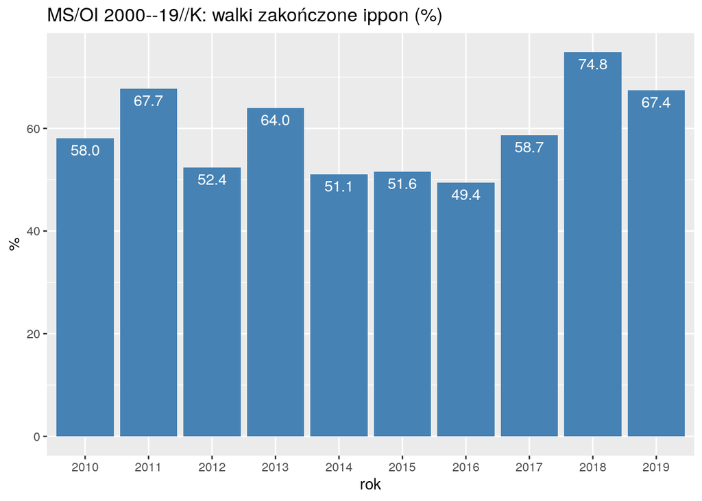

```r
p.f
```

Koniec.